# Machine Learning analysis and prediction

**STEP 1:** -reading the data provided

```r
setwd("C:/Users/Home/Desktop/mlProject")
library(caret)
```

```r
library(ISLR)
library(kernlab)
data=read.table("pml-training.csv",header=F,sep=",",skip=1)
cnames=readLines("pml-training.csv",1)
cnames=strsplit(cnames,",",fixed=T)
cnames[[1]][1]="id"
cnames[[1]][2]=gsub("\"","",cnames[[1]][2])
cnames[[1]][]=gsub("\"","",cnames[[1]][])
names(data)=make.names(cnames[[1]])
```

**STEP 2:** -exploring nan’s and removing columns with number of nan’s bigger than the treshold -exploring “”s and removing columns with number of “”s bigger than the treshold Observation : treshold is set to 40 % of total number of rows

```r
treshold=nrow(data)*(1/2.5)
data=data[,colSums(is.na(data))<=treshold]
data=data[,colSums((data==""))<=treshold]
```

**STEP 3:** Data slicing - creating data partitions

```r
library(ISLR)
library(kernlab)
library(caret)
inTrain=createDataPartition(y=data$classe,p=0.75,list=FALSE)
train=data[inTrain,]
test=data[-inTrain,]
```

**STEP 4:** EXPLORING DATA WITH CLUSTERING

a)-0ne thing we could do is to plot accel belt belt for the firs subject carlitos

```
##  [1] "id"                   "user_name"            "raw_timestamp_part_1"
##  [4] "raw_timestamp_part_2" "cvtd_timestamp"       "new_window"
##  [7] "num_window"           "roll_belt"            "pitch_belt"
## [10] "yaw_belt"             "total_accel_belt"     "gyros_belt_x"
## [13] "gyros_belt_y"
```

```
##
##    A    B    C    D    E
## 4185 2848 2567 2412 2706
```

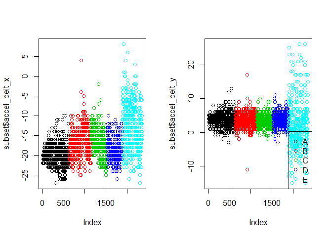

Observation :we can see that there is no very much information regardin accel_belt except E classe

b)-CLUSTERINGs BASED ON accel_belt_x,accel_belt_y,accel_belt_Z here we use myplclust.R for plotting(It is pasted here beacuse when I am tryng source(myplclust.R), I am getting an error)

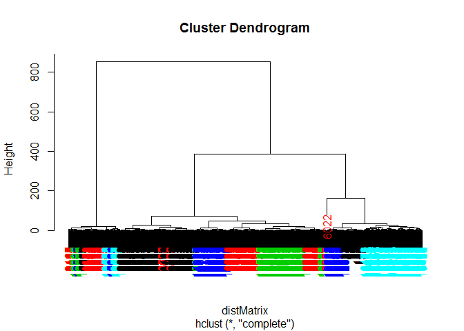

Observation: we can observ it is not very clear the accel_belt features do not appear to be able to discriminate between the 5 different classe’s.

c)-SINGULAR VALUE DECOMPOSITION

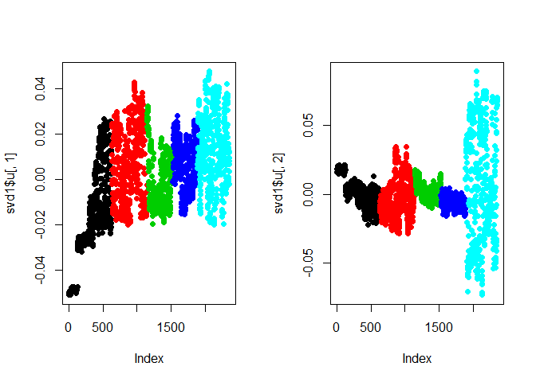

Observation : no results

d)-New clustering with the maximum contributor and k-means

```
## [1] "raw_timestamp_part_2"
```

```
##
##       A   B   C   D   E
##   1 433 144 174  65  27
##   2  65 123   8  66  56
##   3  37  72  37  82 129
##   4  16  70  50  35 168
##   5  74 112 111 114  88
```

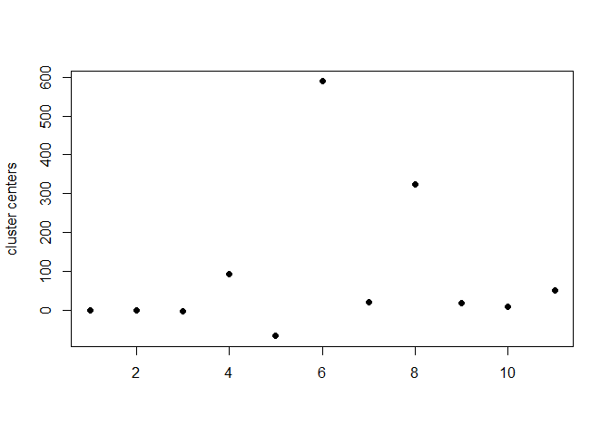

*CONCLUSION : With clustering and k-means we can’t find relevant information that can help in prediction(clustering was made like the one in clustering case study from Exploratory Data Analysis)*

**STEP 5:** Removing zero covariates(with lowest percent unique)and columns with zero information and repartition data:

```r
nzv=nearZeroVar(data,saveMetrics=T)#one  nzv  value
data=data[,-c(1,2,3,4,5,6,7)]
inTrain=createDataPartition(y=data$classe,p=0.75,list=FALSE)
train=data[inTrain,]
test=data[-inTrain,]
```

**STEP 6:** Preprocessing with PCA creating the correlation matrix(to see what features are strongly corellated)

```r
m=abs(cor(train[,-length(colnames(train))]))
diag(m)=0
which(m>0.8,arr.ind=T)
```

```
##                  row col
## yaw_belt           3   1
## total_accel_belt   4   1
## accel_belt_y       9   1
## accel_belt_z      10   1
## accel_belt_x       8   2
## magnet_belt_x     11   2
## roll_belt          1   3
## roll_belt          1   4
## accel_belt_y       9   4
## accel_belt_z      10   4
## pitch_belt         2   8
## magnet_belt_x     11   8
## roll_belt          1   9
## total_accel_belt   4   9
## accel_belt_z      10   9
## roll_belt          1  10
## total_accel_belt   4  10
## accel_belt_y       9  10
## pitch_belt         2  11
## accel_belt_x       8  11
## gyros_arm_y       19  18
## gyros_arm_x       18  19
## magnet_arm_x      24  21
## accel_arm_x       21  24
## magnet_arm_z      26  25
## magnet_arm_y      25  26
## accel_dumbbell_x  34  28
## accel_dumbbell_z  36  29
## gyros_dumbbell_z  33  31
## gyros_forearm_z   46  31
## gyros_dumbbell_x  31  33
## gyros_forearm_z   46  33
## pitch_dumbbell    28  34
## yaw_dumbbell      29  36
## gyros_forearm_z   46  45
## gyros_dumbbell_x  31  46
## gyros_dumbbell_z  33  46
## gyros_forearm_y   45  46
```

```r
preProcess.default(x = train[,-length(colnames(train))], method = "pca", thresh = 0.90)
```

```
##
## Call:
## preProcess.default(x = train[, -length(colnames(train))], method =
##  "pca", thresh = 0.9)
##
## Created from 14718 samples and 52 variables
## Pre-processing: principal component signal extraction, scaled, centered
##
## PCA needed 18 components to capture 90 percent of the variance
```

**STEP 6:** TRYNG DIFFERENT MACHINE LEARNING ALGORITHMS *A*-Predictiong with *glm* not working - it works only for 2 outcomes

*B*-Predicting with *trees* and analyse accuracy with *pca* and non pca

-without pca

```r
modFit=train(classe~.,method="rpart",data=train)
pred=predict(modFit,newdata=test)
c=confusionMatrix(pred,test$classe)
print(c)
```

```
## Confusion Matrix and Statistics
##
##           Reference
## Prediction    A    B    C    D    E
##          A 1262  387  387  343  144
##          B   34  343   28  150  126
##          C   94  219  440  311  230
##          D    0    0    0    0    0
##          E    5    0    0    0  401
##
## Overall Statistics
##
##                Accuracy : 0.499
##                  95% CI : (0.485, 0.513)
##     No Information Rate : 0.284
##     P-Value [Acc > NIR] : <2e-16
##
##                   Kappa : 0.345
##  Mcnemar's Test P-Value : NA
##
## Statistics by Class:
##
##                      Class: A Class: B Class: C Class: D Class: E
## Sensitivity             0.905   0.3614   0.5146    0.000   0.4451
## Specificity             0.641   0.9145   0.7891    1.000   0.9988
## Pos Pred Value          0.500   0.5037   0.3400      NaN   0.9877
## Neg Pred Value          0.944   0.8565   0.8850    0.836   0.8888
## Prevalence              0.284   0.1935   0.1743    0.164   0.1837
## Detection Rate          0.257   0.0699   0.0897    0.000   0.0818
## Detection Prevalence    0.514   0.1389   0.2639    0.000   0.0828
## Balanced Accuracy       0.773   0.6380   0.6519    0.500   0.7219
```

-with pca

```r
modelFit <- train(train$classe ~ ., method = "rpart", preProcess = "pca",
                                    data = train, trControl = trainControl(preProcOptions = list(thresh = 0.8)))
pred=predict(modelFit,newdata=test)
c=confusionMatrix(pred,test$classe)
print(c)
```

```
## Confusion Matrix and Statistics
##
##           Reference
## Prediction    A    B    C    D    E
##          A 1047  413  552  272  235
##          B  296  450  289  353  376
##          C    0    0    0    0    0
##          D    0    0    0    0    0
##          E   52   86   14  179  290
##
## Overall Statistics
##
##                Accuracy : 0.364
##                  95% CI : (0.351, 0.378)
##     No Information Rate : 0.284
##     P-Value [Acc > NIR] : <2e-16
##
##                   Kappa : 0.165
##  Mcnemar's Test P-Value : NA
##
## Statistics by Class:
##
##                      Class: A Class: B Class: C Class: D Class: E
## Sensitivity             0.751   0.4742    0.000    0.000   0.3219
## Specificity             0.581   0.6678    1.000    1.000   0.9173
## Pos Pred Value          0.416   0.2551      NaN      NaN   0.4670
## Neg Pred Value          0.854   0.8411    0.826    0.836   0.8573
## Prevalence              0.284   0.1935    0.174    0.164   0.1837
## Detection Rate          0.213   0.0918    0.000    0.000   0.0591
## Detection Prevalence    0.514   0.3597    0.000    0.000   0.1266
## Balanced Accuracy       0.666   0.5710    0.500    0.500   0.6196
```

*Conclusion :* The results are not looking ok :D

*C*-PREDICTING WITH BAGGING(TREES)->>avg of the results of trees where each tree corresponds to a subsample

```r
predictors=data.frame(train[,-length(colnames(train))])
y=train$classe
bagtree=bag(predictors,y,B=4,bagControl=bagControl(fit=ctreeBag$fit,predict=ctreeBag$pred,aggregate=ctreeBag$aggregate))
testbag=data.frame(test[,-length(colnames(test))])
p=predict(bagtree,testbag)
c=confusionMatrix(p,test$classe)
print(c)
```

```
## Confusion Matrix and Statistics
##
##           Reference
## Prediction    A    B    C    D    E
##          A 1361   40    7    8    6
##          B   24  863   24   11   13
##          C    4   25  800   34    9
##          D    6   15    6  742    5
##          E    0    6   18    9  868
##
## Overall Statistics
##
##                Accuracy : 0.945
##                  95% CI : (0.938, 0.951)
##     No Information Rate : 0.284
##     P-Value [Acc > NIR] : < 2e-16
##
##                   Kappa : 0.93
##  Mcnemar's Test P-Value : 3.7e-05
##
## Statistics by Class:
##
##                      Class: A Class: B Class: C Class: D Class: E
## Sensitivity             0.976    0.909    0.936    0.923    0.963
## Specificity             0.983    0.982    0.982    0.992    0.992
## Pos Pred Value          0.957    0.923    0.917    0.959    0.963
## Neg Pred Value          0.990    0.978    0.986    0.985    0.992
## Prevalence              0.284    0.194    0.174    0.164    0.184
## Detection Rate          0.278    0.176    0.163    0.151    0.177
## Detection Prevalence    0.290    0.191    0.178    0.158    0.184
## Balanced Accuracy       0.979    0.946    0.959    0.958    0.978
```

*D*-PREDICTING WITH random forest (EXTENSION OF BAGGING- DIFFERENCE 0 AT EACH SPLIT BOOTSRAP VARIABLES)attention y must be factor otherwise it will make regression

```r
library(randomForest)
modelFit=randomForest(classe~.,data=train,ntree=300)
p=predict(modelFit,test)
c=confusionMatrix(p,test$classe)
print(c)
```

```
## Confusion Matrix and Statistics
##
##           Reference
## Prediction    A    B    C    D    E
##          A 1394    1    0    0    0
##          B    1  947    3    0    0
##          C    0    1  852    8    0
##          D    0    0    0  796    2
##          E    0    0    0    0  899
##
## Overall Statistics
##
##                Accuracy : 0.997
##                  95% CI : (0.995, 0.998)
##     No Information Rate : 0.284
##     P-Value [Acc > NIR] : <2e-16
##
##                   Kappa : 0.996
##  Mcnemar's Test P-Value : NA
##
## Statistics by Class:
##
##                      Class: A Class: B Class: C Class: D Class: E
## Sensitivity             0.999    0.998    0.996    0.990    0.998
## Specificity             1.000    0.999    0.998    1.000    1.000
## Pos Pred Value          0.999    0.996    0.990    0.997    1.000
## Neg Pred Value          1.000    0.999    0.999    0.998    1.000
## Prevalence              0.284    0.194    0.174    0.164    0.184
## Detection Rate          0.284    0.193    0.174    0.162    0.183
## Detection Prevalence    0.284    0.194    0.176    0.163    0.183
## Balanced Accuracy       0.999    0.998    0.997    0.995    0.999
```

inBuild=createDataPartition(y=data$classe,p=0.7,list=F)

validation=data[-inBuild,]

buildData=data[inBuild,]

inTrain=createDataPartition(y=buildData$classe,p=0.7,list=F)

training=buildData[inTrain,]

testing=buildData[-inTrain,]

pred1=predict(modelBoosting,testing)

pred2=predict(modelRandomFores,testing)

qplot(pred1,pred2,data=test) in case it is regression problem

predDF=data.frame(pred1,pred2,classe=testing$classe)

combPred=predict(comb,predDF)